# EPL Match Analysis Project

## I. Background and Introduction

The English Premier League (EPL) offers a rich laboratory for studying how match outcomes and scoring patterns evolve across time and contexts. Tactical cycles, scheduling demands, and broader league dynamics can all affect the balance between attack and defense, whereas the long-observed home advantage raises questions about how consistently it appears and for whom. By analyzing matches with clear methods, we can offer analysts and fans an insight on whether impressions from a few games match the full season data.

This project focuses on five concrete questions: whether average goals per match have shifted by season; how the distribution of total goals in a match looks like; how home win, away win and draw percentages change over time; whether there is a persistent home scoring edge when comparing average home and away goals; and whether that edge and win rates differs between top-tier and bottom-tier clubs. Understanding these dynamics is useful for multiple audiences. Analysts can calibrate forecasting priors around realistic goal totals and outcome probabilities; coaches and commentators gain a clearer sense of "eras" of play; and fans can see how advantages vary with team quality.

## II. Data Preprocessing and Methodology

The analysis aggregates season-level match results for all Premier League matches from season 2010-2011 to 2024-2025 taken from https://www.football-data.co.uk/englandm.php. From the raw data sets, we append a `Season` label so that trends can be summerized over time. Core variables in our analysis include full-time home goals, full-time away goals, and the full-time result, which encodes home wins, draws, and away wins. A new variable, total match goals, supports both seasonal averages and goal-count distributions. For comparisons between top-tier and bottom-tier teams, we get season standings data from Kaggle (https://www.kaggle.com/datasets/evangower/english-premier-league-standings) and the official Premier League website (https://www.premierleague.com/en/tables?competition=8&season=2024&round=L_1&matchweek=-1&ha=-1) and standardized team names so that they are consistent with the matches datasets.

To clean and process data, we first load the match datasets for each season, assign its season tag, and concatenate into a single match DataFrame. Then, we compute total goals for each match, overall and per-season outcome rates, average home and away goals per season and their difference as a reference for home scoring edge. Finally, we merge match data with season standings data to compare win percentages for top-five and bottom-five clubs at home and away. We also use different plots to visualize the trends and changes in rates and number of goals scored over time. The design of this analysis is descriptive: it characterizes patterns without adjusting for factors such as opponent strength, fixture congestion, injuries, or tactical shifts. This makes our analysis easy to follow while leaving room for more advanced modeling in future work.

## III. Exploration and Results

Now, we will import necessary libraries and import data for our analysis.

```python
# Import libraries
import pandas as pd
import matplotlib.pyplot as plt
```

For each season's match data, we add a new variable `Season` to identify which season the match is in before merging into one big data set. This allows for easier analysis later on.

```python
# Load data
dfs = []

for year in range (2010, 2025):
    # Build suffix for CSV name
    suffix = f"{year%100:02d}{(year+1)%100:02d}"
    # Build season label
    label = f"{year%100:02d}-{(year+1)%100:02d}"
    # Load CSV file
    filename = f"data/EPL_{suffix}.csv"
    df = pd.read_csv(filename)
    df = df.assign(Season = label)
    dfs.append(df)

# Concatenate data
epl = pd.concat(dfs, ignore_index=True)
```

### Average goals per match by season

For analyzing average goals per match by season, for each match, we create a new variable for total goals per match. Then, we calculate average goals per match by season and then create a line plot to visualize the trends of this variable over the seasons and compare it with overall average.

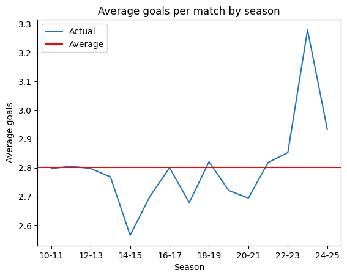

```python
# Calculate total goals per match
epl = epl.assign(FTGoals = lambda epl: epl["FTHG"] + epl["FTAG"])

# Calculate average goals per match by season
avg = epl["FTGoals"].mean()
avg_goals = epl.groupby(by = "Season")["FTGoals"].mean()
avg_goals.plot(label = "Actual")
plt.axhline(avg, color="r", label = "Average")
plt.title("Average goals per match by season")
plt.xlabel("Season")
plt.ylabel("Average goals")
plt.legend()
plt.show()
```

### Matches Distribution by Number of Goals

Based on the total number of goals per match, we create a bar plot to show how the distribution of the total goals per match looks like.

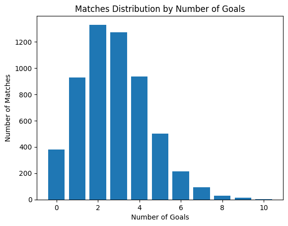

```python
# Overall distribution of goals per match
counts = epl["FTGoals"].value_counts().sort_index()
plt.bar(counts.index, counts)
plt.title("Matches Distribution by Number of Goals")
plt.xlabel("Number of Goals")
plt.ylabel("Number of Matches")

plt.show()
```

### Home and Away Win Probability Analysis

Based on match results, we calculate percentages that home team wins, away team wins, and draws happened. We also created plot to see the trends of these probabilities and compare them together as well as compare these trends to the overall average.

```
        Percentage
Result
H         0.448693
A         0.310998
D         0.240133
```

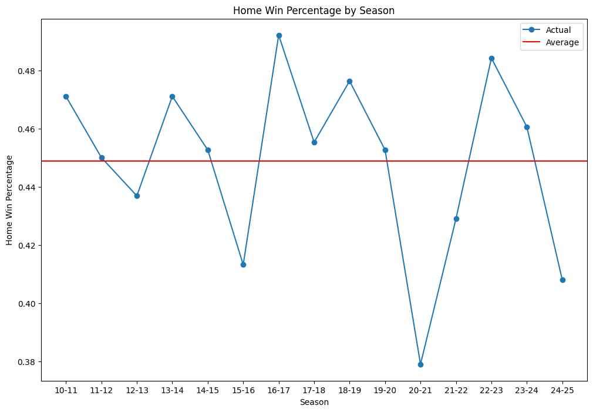

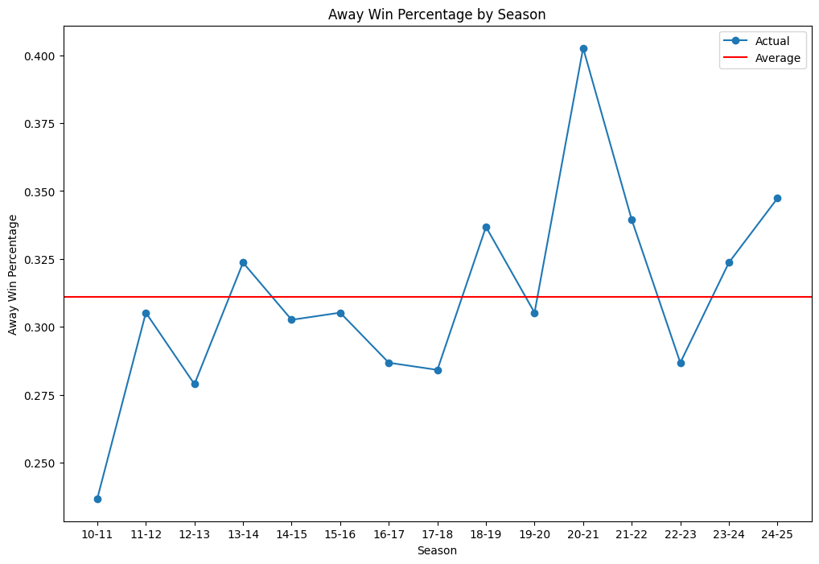

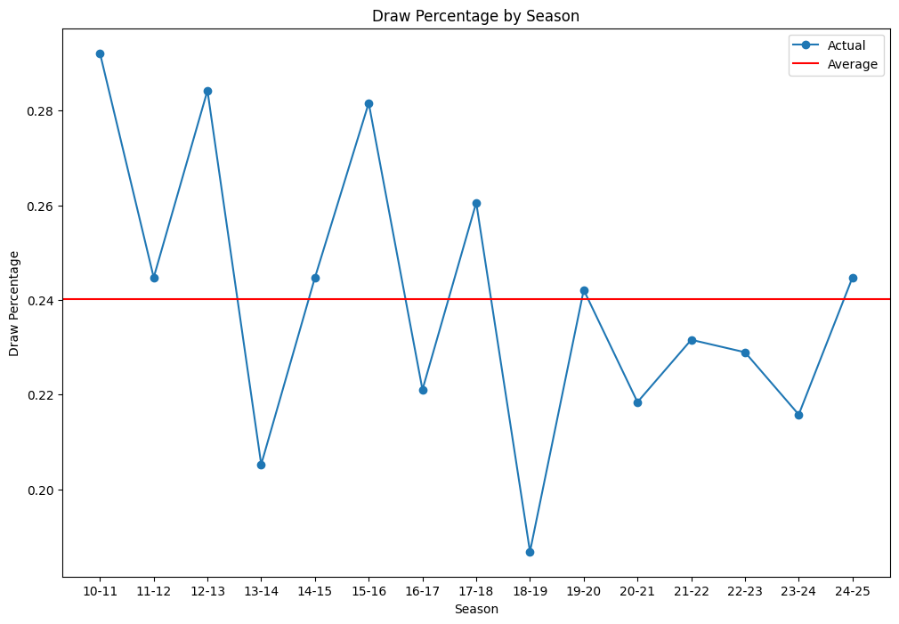

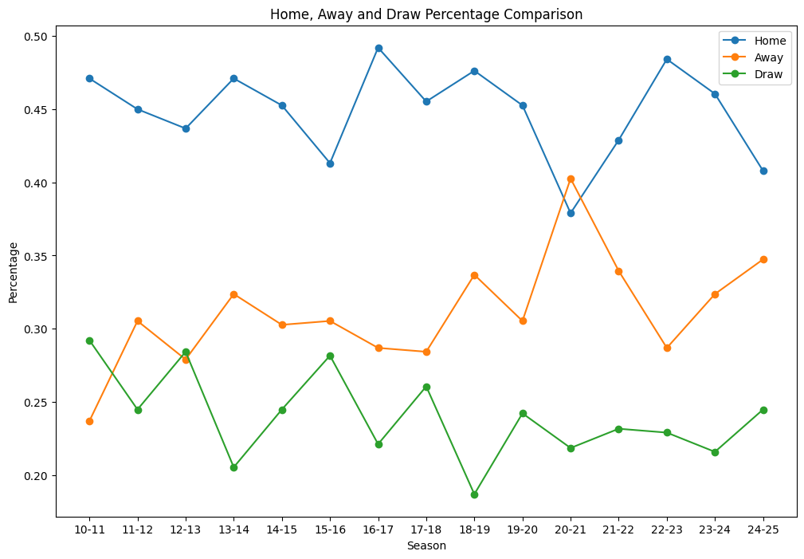

```python
# Win/draw/loss percentage home vs away overall and by season

# Overall percentage home vs away
result_perc = epl['FTR'].value_counts()/len(epl)
result_perc = pd.DataFrame(result_perc)
result_perc = result_perc.rename(columns = {"count" : "Percentage"})
result_perc = result_perc.rename_axis('Result')
print(result_perc)

# Percentage by season
result_perc_by_season = epl.groupby(by = "Season")['FTR'].value_counts()/380
result_perc_by_season = pd.DataFrame(result_perc_by_season)
result_perc_by_season = result_perc_by_season.rename(columns = {"count" : "Percentage"})
home_perc = result_perc_by_season.loc[(slice(None), "H"), :]
home_perc.index = home_perc.index.droplevel('FTR')
away_perc = result_perc_by_season.loc[(slice(None), "A"), :]
away_perc.index = away_perc.index.droplevel('FTR')
draw_perc = result_perc_by_season.loc[(slice(None), "D"), :]
draw_perc.index = draw_perc.index.droplevel('FTR')

fig1, ax1 = plt.subplots(figsize=(12,8))
home_avg = home_perc["Percentage"].mean()
ax1.plot(home_perc.index, home_perc["Percentage"], marker="o", label="Actual")
ax1.axhline(home_avg, color="r", label = "Average")
ax1.set_title("Home Win Percentage by Season")
ax1.set_xlabel("Season")
ax1.set_ylabel("Home Win Percentage")
ax1.legend()
plt.show()

fig2, ax2 = plt.subplots(figsize=(12,8))
away_avg = away_perc["Percentage"].mean()
ax2.plot(away_perc.index, away_perc["Percentage"], marker="o", label="Actual")
ax2.axhline(away_avg, color="r", label = "Average")
ax2.set_title("Away Win Percentage by Season")
ax2.set_xlabel("Season")
ax2.set_ylabel("Away Win Percentage")
ax2.legend()
plt.show()

fig3, ax3 = plt.subplots(figsize=(12,8))
draw_avg = draw_perc["Percentage"].mean()
ax3.plot(draw_perc.index, draw_perc["Percentage"], marker="o", label="Actual")
ax3.axhline(draw_avg, color="r", label = "Average")
ax3.set_title("Draw Percentage by Season")
ax3.set_xlabel("Season")
ax3.set_ylabel("Draw Percentage")
ax3.legend()
plt.show()


fig4, ax4 = plt.subplots(figsize=(12, 8))
ax4.plot(home_perc.index, home_perc["Percentage"], marker="o", label="Home")
ax4.plot(away_perc.index, away_perc["Percentage"], marker="o", label="Away")
ax4.plot(draw_perc.index, draw_perc["Percentage"], marker="o", label="Draw")
ax4.set_title("Home, Away and Draw Percentage Comparison")
ax4.set_xlabel("Season")
ax4.set_ylabel("Percentage")
ax4.legend()
plt.show()
```

### Home and Away Average Number of Goals and Goals Difference per Match

Based on match results, we create two plots to compare changes in home vs away goals over the season and see whether there is a clear home scoring edge by looking at the difference between home and away goals.

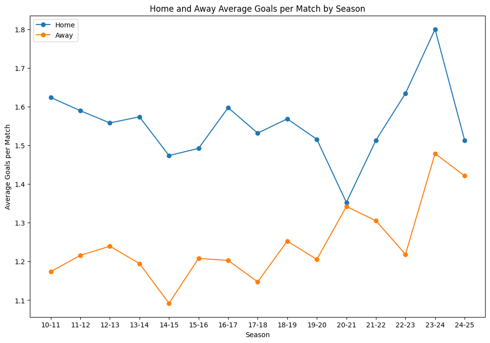

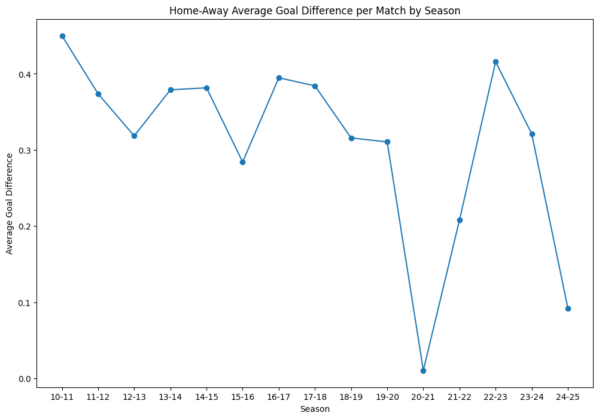

```python
avg_home_goals = epl.groupby(by = "Season")["FTHG"].mean()
avg_away_goals = epl.groupby(by = "Season")["FTAG"].mean()

# Average number of goals per match
fig5, ax5 = plt.subplots(figsize=(12,8))
ax5.plot(avg_home_goals, marker="o", label="Home")
ax5.plot(avg_away_goals, marker="o", label="Away")
ax5.set_title("Home and Away Average Goals per Match by Season")
ax5.set_xlabel("Season")
ax5.set_ylabel("Average Goals per Match")
ax5.legend()
plt.show()

avg_home_goals = pd.DataFrame(avg_home_goals)
avg_away_goals = pd.DataFrame(avg_away_goals)
avg_home_away = pd.concat([avg_home_goals, avg_away_goals], axis=1)
avg_home_away['difference'] = avg_home_away["FTHG"] - avg_home_away["FTAG"]

fig6, ax6 = plt.subplots(figsize=(12,8))
ax6.plot(avg_home_away['difference'], marker="o")
ax6.set_title("Home-Away Average Goal Difference per Match by Season")
ax6.set_xlabel("Season")
ax6.set_ylabel("Average Goal Difference")
plt.show()
```

### Home and Away Advantage Difference between Top 5 and Bottom 5 Teams

We compare the home and away win probabilities between top-tier and bottom-tier teams and visualize their differences and the trends over years.

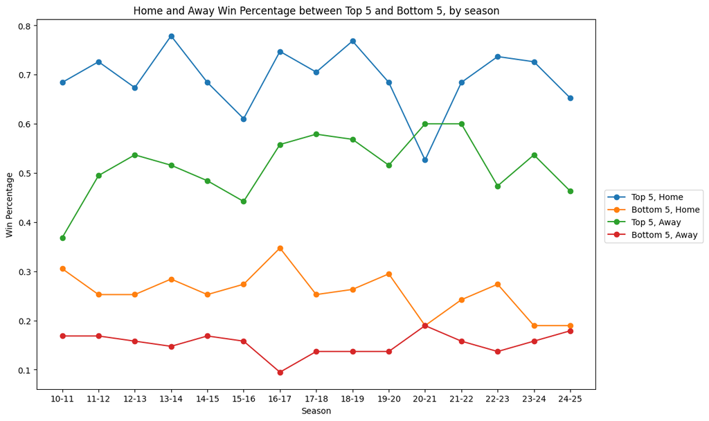

```python
# Get EPL standings for each season
epl_standings = pd.read_csv("data/EPL_standings_93_24.csv")
mapping = {
    'Birmingham City': 'Birmingham',
    'Cardiff City': 'Cardiff',
    'Hull City': 'Hull',
    'Leeds United': 'Leeds',
    'Leicester City': 'Leicester',
    'Luton Town': 'Luton',
    'Manchester City': 'Man City',
    'Manchester Utd': 'Man United',
    'Newcastle Utd': 'Newcastle',
    'Norwich City': 'Norwich',
    "Nottingham Forest": "Nott'm Forest",
    'Sheffield Utd': 'Sheffield United',
    'Stoke City': 'Stoke',
    'Swansea City': 'Swansea',
    'Wigan Athletic': 'Wigan'
}

epl_standings['team'] = epl_standings['team'].replace(mapping)
epl_standings = epl_standings.loc[epl_standings['season_end_year'] >= 2011]
epl_standings.rename(columns = {'season_end_year': 'season'}, inplace = True)

mapping1 = {2011: '10-11', 2012: '11-12', 2013: '12-13', 2014: '13-14', 2015: '14-15',
            2016: '15-16', 2017: '16-17', 2018: '17-18', 2019: '18-19', 2020: '19-20',
            2021: '20-21', 2022: '21-22', 2023: '22-23', 2024: '23-24'}

epl_standings['season'] = epl_standings['season'].replace(mapping1)
merged_epl_home = pd.merge(epl, epl_standings, left_on = ['Season', 'HomeTeam'], right_on = ['season', 'team'])
merged_epl_away = pd.merge(epl, epl_standings, left_on = ['Season', 'AwayTeam'], right_on = ['season', 'team'])

top5_home = merged_epl_home.loc[merged_epl_home['position'] <= 5]
bottom5_home = merged_epl_home.loc[merged_epl_home['position'] >= 16]
top5_away = merged_epl_away.loc[merged_epl_away['position'] <= 5]
bottom5_away = merged_epl_away.loc[merged_epl_away['position'] >= 16]

top5_home_25 = epl.loc[(epl['HomeTeam'].isin(['Liverpool', 'Arsenal', 'Man City', 'Chelsea', 'Newcastle'])) &
                       (epl['Season'] == '24-25')]
bottom5_home_25 = epl.loc[(epl['HomeTeam'].isin(['Wolves', 'Tottenham', 'Leicester', 'Ipswich', 'Southampton'])) &
                          (epl['Season'] == '24-25')]
top5_away_25 = epl.loc[(epl['AwayTeam'].isin(['Liverpool', 'Arsenal', 'Man City', 'Chelsea', 'Newcastle'])) &
                       (epl['Season'] == '24-25')]
bottom5_away_25 = epl.loc[(epl['AwayTeam'].isin(['Wolves', 'Tottenham', 'Leicester', 'Ipswich', 'Southampton'])) &
                          (epl['Season'] == '24-25')]


top5_home = pd.concat([top5_home, top5_home_25])
bottom5_home = pd.concat([bottom5_home, bottom5_home_25])
top5_away = pd.concat([top5_away, top5_away_25])
bottom5_away = pd.concat([bottom5_away, bottom5_away_25])

top5_home = top5_home.assign(is_home_win = (top5_home['FTR'] == 'H'))
top5_home_perc = top5_home.groupby(by = "Season")['is_home_win'].mean()
bottom5_home = bottom5_home.assign(is_home_win = (bottom5_home['FTR'] == 'H'))
bottom5_home_perc = bottom5_home.groupby(by = "Season")['is_home_win'].mean()
top5_away = top5_away.assign(is_away_win = (top5_away['FTR'] == 'A'))
top5_away_perc = top5_away.groupby(by = "Season")['is_away_win'].mean()
bottom5_away = bottom5_away.assign(is_away_win = (bottom5_away['FTR'] == 'A'))
bottom5_away_perc = bottom5_away.groupby(by = "Season")['is_away_win'].mean()

fig7, ax7 = plt.subplots(figsize=(12,8))
ax7.plot(top5_home_perc, marker="o", label="Top 5, Home")
ax7.plot(bottom5_home_perc, marker="o", label="Bottom 5, Home")
ax7.plot(top5_away_perc, marker="o", label="Top 5, Away")
ax7.plot(bottom5_away_perc, marker="o", label="Bottom 5, Away")
ax7.set_title("Home and Away Win Percentage between Top 5 and Bottom 5, by season")
ax7.set_xlabel("Season")
ax7.set_ylabel("Win Percentage")
ax7.legend(loc = 'upper right', bbox_to_anchor = (1.2, 0.55))
plt.show()
```